# TP

# Congruence Lineaire

On implémente un algorithme générique pour générateur à congruence linéaire

## Question 1

```r
congruenceLineaire <- function(graine , a , b , m , n){
  seed <- rep(graine,n)

  for(i in 2:n){
    seed[i] <- (a*seed[i-1] + b)%%m
  }

  return (seed)
}
```

```r
RANDU <- function(graine = 69420 , n){
  a <- 65539
  b <- 0
  m <- 2^31
  return (congruenceLineaire(graine, a , b , m , n))
}
```

### Standard Minimal

```r
standardMinimal <- function(graine = 69420, n){
  a <- 16807
  b <- 0
  m <- 2^31 - 1

  return (congruenceLineaire(graine , a , b , m , n))
}
```

### VonNeumann

```r
VonNeumann <- function(n, p=1, graine)
{
  x <-  rep(graine,n*p+1)
  for(i in 2:(n*p+1))
  {
    numbers <- strsplit(format(x[i-1]^2,scientific=FALSE),'')[[1]]
    while(length(numbers)>4){
        numbers <- numbers[2:(length(numbers)-1)]
    }
    x[i] <- as.numeric(numbers)%*%(10^seq(length(numbers)-1,0,-1))
  }
  x <- matrix(x[2:(n*p+1)],nrow=n,ncol=p)
  return(x)
}
```

### Mersenne-Twister

```r
MersenneTwister <- function(n, p=1, graine)
{
  set.seed(graine,kind='Mersenne-Twister')
  x <- sample.int(2^32-1,n*p)
  x <- matrix(x,nrow=n,ncol=p)
  return(x)
}
```

## Question 2

### 2.1

#### RANDU

```r
testStatistiques <- function(k) {
  par(mfrow = c(2,2))
  hist(RANDU(graine = 215, n = k) , xlab = "Valeur" , ylab = "fréquence" , main = "RANDU")
  hist(standardMinimal(graine = 215 , n = k) , xlab = "Valeur" , ylab = "fréquence" , main = "Standard Minimal")
  hist(VonNeumann(n = k , graine = 215), main = "Von Neumann")
  hist(MersenneTwister(n = k, graine = 215), main = "Mersenne-Twister")
}
```

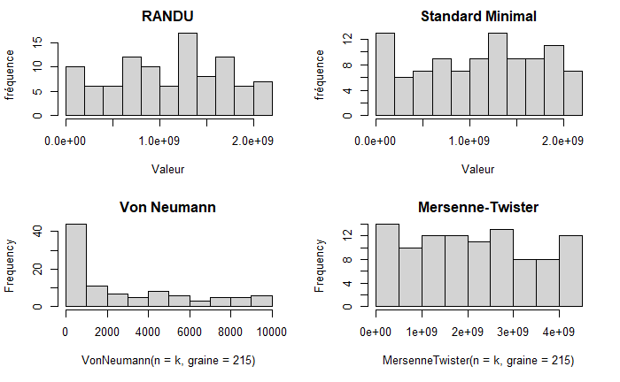

```r
testStatistiques(100)
```

### 2.2

#### S(n) = f(S(n-1))

On trace $S_n = f(S_{n-1})$

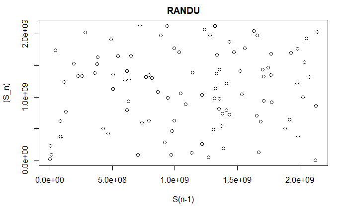

```r
n = 100
u_RANDU <- RANDU(graine = 215, n =100)
u_SM <- standardMinimal(graine = 215, n =100)
u_VonNeumann <- VonNeumann(n = 100, graine = 215)
u_MersenneTwister <- MersenneTwister(n = 100 , graine = 215)


plot(u_RANDU[1:(n-1)] , u_RANDU[2:n] , xlab = "S(n-1)" , ylab = "(S_n)", main = "RANDU")
```

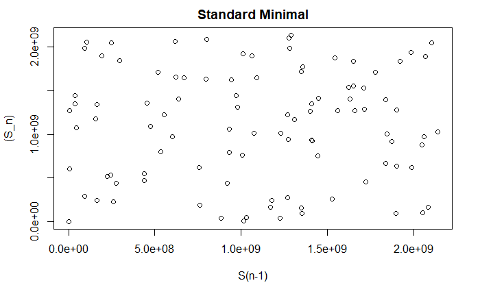

```r
plot(u_SM[1:(n-1)] , u_SM[2:n] , xlab = "S(n-1)" , ylab = "(S_n)" , main = "Standard Minimal")
```

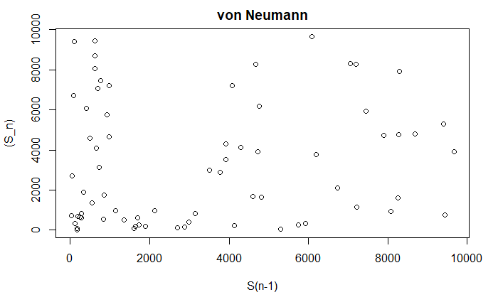

```r
plot(u_VonNeumann[1:(n-1)] , u_VonNeumann[2:n] , xlab = "S(n-1)" , ylab = "(S_n)", main = "von Neumann")
```

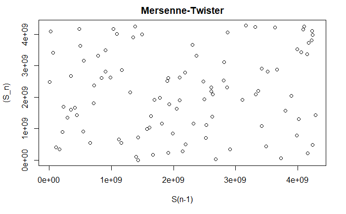

```r
plot(u_MersenneTwister[1:(n-1)] , u_MersenneTwister[2:n] , xlab = "S(n-1)" , ylab = "(S_n)" , main = "Mersenne-Twister")
```

La représentation graphique montre comment chaque nombre dans la séquence générée dépend de son prédécesseur. Plus précisément, les coordonnées $S_{n-1}~,~ S_n$ pour chaque n représentent les points dans un nuage de points. Les coordonnées correspondent aux valeurs des nombres aléatoires générés, où `S(n-1)` est la valeur de l’élément précédent dans la séquence et $Sn$ est la valeur actuelle.

Si on se contente d’observer $S_n = f(S_{n-1})$ alors on peut penser que la génération se fait de manière aléatoire, cependant, le seed donné initialement détermine toujours la output de l’algortithme à un certain ordre N.

En d’autres termes, la méthode RANDU a des propriétés qui peuvent entraîner une apparence aléatoire des points dans le nuage de points, même si les nombres générés ne sont pas vraiment aléatoires. Par exemple, les points peuvent sembler être répartis de manière uniforme sur le graphique, même si des motifs répétitifs existent.

## Test de fréquence monobit

```r
binary <- function(x)
{
  if((x<2^31)&(x>=0))
    return( as.integer(intToBits(as.integer(x))) )
  else{
    if((x<2^32)&(x>0))
      return( c(binary(x-2^31)[1:31], 1) )
    else{
      cat('Erreur dans binary : le nombre etudie n est pas un entier positif en 32 bits.\n')
      return(c())
    }
  }
}
```

### Implémentation

On commence par implémenter la fonction de calcul du nombre de bits à 1

```r
Frequency <- function(x , nb = 32){

  binarySequence <- sapply(x , binary)

  binarySequence <- binarySequence[1 : nb,]

  bb <- matrix(binarySequence, nrow = nb*length(x))

  r <- sum(2*bb[1:length(bb)] - 1)

  s_obs <- abs(r)/sqrt(nb*length(x))

  p_value <- 2 * (1 - pnorm(s_obs))

  return (p_value)
}

Frequency2 <- function(x,nb){
  s <- rep(0,length(x))
  for(i in 1:length(x)){
    bSeq <- binary(x[i])[1:nb]
    s[i] <- sum(2 * bSeq[1:nb] - 1)
  }

  s_obs <- abs(sum(s))/sqrt(nb * length(x))

  p_value <- 2 * (1 - pnorm(s_obs))

  return (p_value)
}
```

### Tests

```r
set.seed(555)

u1 <- sample.int(10000 , 100)
freq_RANDU <- c()
freq_SM <- c()
freq_VonNeumann <- c()
freq_MersenneTwister <- c()

for(i in 1:length(u1)){
  u_RANDU <- RANDU(graine = u1[i], n = 200)
  u_SM <- standardMinimal(graine = u1[i] , n = 200)
  u_VonNeumann <- VonNeumann(graine = u1[i] , n = 200)
  u_MersenneTwister <- MersenneTwister(graine = u1[i] , n = 200)
  freq_RANDU <- c(freq_RANDU,Frequency(u_RANDU , 31))
  freq_SM <- c(freq_SM,Frequency(u_SM , 31))
  freq_VonNeumann <- c(freq_VonNeumann,Frequency(u_VonNeumann , 14))
  freq_MersenneTwister <- c(freq_MersenneTwister,Frequency(u_MersenneTwister))
}

# Nombre de valeurs inferieures à 0.01
n_RANDU <- length(which(freq_RANDU < 0.01))
n_SM <- length(which(freq_SM < 0.01))
n_VonNeumann <- length(which(freq_VonNeumann < 0.01))
n_MersenneTwister <- length(which(freq_MersenneTwister < 0.01))
```